# AI_Assessment

**INTRODUCTION :**

In the fast-growing world of e-commerce, companies generate large amounts of data, if that data is analysed properly, we can easily use it for growing business expansion and enhance customer satisfaction.. Flipkart is one of India’s leading online marketplaces, sells millions of products in wide range of categories such as clothing, footwear, electronics, furniture, and more. Each product has metadata including its brand, price, discount, rating, category hierarchy, and specifications.

This project is done on publicly available dataset from Kaggle on Flipkart products listings to perform Exploratory Data Analysis (EDA). The main aim is to find out useful business insights of the dataset which has seven months information 2015-12-01 to 2016-06-28,it can help the organization to answer the critical questions for themselves to know more about their company, such as:

• Which product and brands are most popular in the market?

• In what way discounts are impacting price strategies and sales performances?

• In What pattern customers are giving ratings and reviews of the product?

• How can product attributes like brand, specifications and category hierarchy can be utilized for better marketing and inventory decisions?

Product unique ID,Brand,price discount are the crucial elements in the data set makes the company to understand better about the sales in this research.

OBJECTIVES of the project:

- Cleaning and Exploring the data to answer the business questions which makes the busniess better.
- Perform exploratory data analysis (EDA) to understand sales.

**Data Source:**

The project is predicted on organized data and below mentioned some essential characteristics which are given in the data set along with the link.

1. Uniq_id :
2. Product category:
3. Brand:
4. Discount:
5. Price :

LINK : https://www.kaggle.com/datasets/atharvjairath/flipkart-ecommerce-dataset/data

**Business problem statement:**

Flipkart has many products in different categories, but not all perform equally good in terms of sales and customer satisfaction. The company needs to know which categories, brands, prices, and discounts are attracting large number of customers, and which products are underperforming. By analyzing the product data such as prices, discounts, ratings, and categories, Fl ipkart can make better decisions to improve their sales and customer experience for better.

# Data Exploration and Cleaning

```python
# Importing the required libraries.

import pandas as pd #A Python library used to read/write the files and manipulation, mainly on DataFrames.
import numpy as np #For math with array of numbers.
import matplotlib as mpl #For visualization of charts and graphs
import matplotlib.pyplot as plt #For line,bar,scatter graphs
import seaborn as sns #To make the plots look better & easier with fewer lines of code.
```

```python
#Loading the Dataset
df_org = pd.read_csv("/content/flipkart_com-ecommerce_sample.csv")

#Displaying shape of the dataset and NaN values and the first 5 rows of the dataset.
print(df_org.shape)
print("count of nan:",df_org.isna().sum().sum())
display(df_org.head(5))
```

```
(20002, 15)
count of nan: 6069
```

|  | uniq_id | crawl_timestamp | product_url | product_name | product_category_tree | pid | retail_price | discounted_price | image | is_FK_Advantage_product | description | product_rating | overall_rating | brand | product_specifications |
| --- | --- | --- | --- | --- | --- | --- | --- | --- | --- | --- | --- | --- | --- | --- | --- |
| 0 | c2d766ca982eca8304150849735ffef9 | 2016-03-25 22:59:23 +0000 | http://www.flipkart.com/alisha-solid-women-s-c... | Alisha Solid Women's Cycling Shorts | ["Clothing >> Women's Clothing >> Lingerie, Sl... | SRTEH2FF9KEDEFGF | 999.0 | 379.0 | ["http://img5a.flixcart.com/image/short/u/4/a/... | False | Key Features of Alisha Solid Women's Cycling S... | No rating available | No rating available | Alisha | {"product_specification"=>[{"key"=>"Number of ... |
| 1 | 7f7036a6d550aaa89d34c77bd39a5e48 | 2016-03-25 22:59:23 +0000 | http://www.flipkart.com/fabhomedecor-fabric-do... | FabHomeDecor Fabric Double Sofa Bed | ["Furniture >> Living Room Furniture >> Sofa B... | SBEEH3QGU7MFYJFY | 32157.0 | 22646.0 | ["http://img6a.flixcart.com/image/sofa-bed/j/f... | False | FabHomeDecor Fabric Double Sofa Bed (Finish Co... | No rating available | No rating available | FabHomeDecor | {"product_specification"=>[{"key"=>"Installati... |
| 2 | f449ec65dcbc041b6ae5e6a32717d01b | 2016-03-25 22:59:23 +0000 | http://www.flipkart.com/aw-bellies/p/itmeh4grg... | AW Bellies | ["Footwear >> Women's Footwear >> Ballerinas >... | SHOEH4GRSUBJGZXE | 999.0 | 499.0 | ["http://img5a.flixcart.com/image/shoe/7/z/z/r... | False | Key Features of AW Bellies Sandals Wedges Heel... | No rating available | No rating available | AW | {"product_specification"=>[{"key"=>"Ideal For"... |
| 3 | 0973b37acd0c664e3de26e97e5571454 | 2016-03-25 22:59:23 +0000 | http://www.flipkart.com/alisha-solid-women-s-c... | Alisha Solid Women's Cycling Shorts | ["Clothing >> Women's Clothing >> Lingerie, Sl... | SRTEH2F6HUZMQ6SJ | 699.0 | 267.0 | ["http://img5a.flixcart.com/image/short/6/2/h/... | False | Key Features of Alisha Solid Women's Cycling S... | No rating available | No rating available | Alisha | {"product_specification"=>[{"key"=>"Number of ... |
| 4 | bc940ea42ee6bef5ac7cea3fb5cfbee7 | 2016-03-25 22:59:23 +0000 | http://www.flipkart.com/sicons-all-purpose-arn... | Sicons All Purpose Arnica Dog Shampoo | ["Pet Supplies >> Grooming >> Skin & Coat Care... | PSOEH3ZYDMSYARJ5 | 220.0 | 210.0 | ["http://img5a.flixcart.com/image/pet-shampoo/... | False | Specifications of Sicons All Purpose Arnica Do... | No rating available | No rating available | Sicons | {"product_specification"=>[{"key"=>"Pet Type",... |

```python
df = df_org.copy() #Copied original DataFrame
df.isna().sum()    #Checks missing NaN and counts how many values are in each the column are missing.
```

|  | 0 |
| --- | --- |
| uniq_id | 2 |
| crawl_timestamp | 2 |
| product_url | 2 |
| product_name | 2 |
| product_category_tree | 2 |
| pid | 2 |
| retail_price | 80 |
| discounted_price | 80 |
| image | 5 |
| is_FK_Advantage_product | 2 |
| description | 4 |
| product_rating | 2 |
| overall_rating | 2 |
| brand | 5866 |
| product_specifications | 16 |

**dtype:** int64

Filling the missing NaN values.

```python
df = df_org.copy()    #Copied dataset so original one is safe and any changes below don’t overwrite it.

#Filling critical IDs/names with placeholders instead of dropping,so this replacing missing values prevents errors in the analysis.
df['uniq_id'] = df['uniq_id'].fillna('Unknown_ID')
df['pid'] = df['pid'].fillna('Unknown_PID')
df['product_url'] = df['product_url'].fillna('No_URL')
df['product_name'] = df['product_name'].fillna('Unnamed Product')

#Prices are numeric so filling the missing values with median to avoid skewing the data
df['retail_price'] = df['retail_price'].fillna(df['retail_price'].median())
df['discounted_price'] = df['discounted_price'].fillna(df['discounted_price'].median())

#Ensureing the discounted price is not higher than retail price to fix inconsistency of the data.
df.loc[df['discounted_price'] > df['retail_price'], 'discounted_price'] = df['retail_price']

#Replacing the missing values with defaults,so all products have complete info.
df['image'] = df['image'].fillna('No image available')
df['is_FK_Advantage_product'] = df['is_FK_Advantage_product'].fillna(False)
df['description'] = df['description'].fillna('No description provided')
df['brand'] = df['brand'].fillna('Unknown')
df['product_specifications'] = df['product_specifications'].fillna('Not specified')
df['product_category_tree'] = df['product_category_tree'].fillna('["Uncategorized"]')

#Converting ratings to numeric and filling the missing data with median to ensure consistency for calculations.
df['product_rating'] = df['product_rating'].replace('No rating available', np.nan).astype(float)
df['overall_rating'] = df['overall_rating'].replace('No rating available', np.nan).astype(float)
df['product_rating'] = df['product_rating'].fillna(df['product_rating'].median())
df['overall_rating'] = df['overall_rating'].fillna(df['overall_rating'].median())

#Filling missing values with the most common timestamp to avoid errors in temporal analysis.
df['crawl_timestamp'] = pd.to_datetime(df['crawl_timestamp'], errors='coerce')
df['crawl_timestamp'] = df['crawl_timestamp'].fillna(df['crawl_timestamp'].mode()[0])

print("Remaining null values after cleaning:")
print(df.isna().sum())
print("Shape before filling:", df.shape)
print("Shape after filling:", df.shape)
```

```
Remaining null values after cleaning:
uniq_id                    0
crawl_timestamp            0
product_url                0
product_name               0
product_category_tree      0
pid                        0
retail_price               0
discounted_price           0
image                      0
is_FK_Advantage_product    0
description                0
product_rating             0
overall_rating             0
brand                      0
product_specifications     0
dtype: int64
Shape before filling: (20002, 15)
Shape after filling: (20002, 15)
```

```python
# Showing dataset info

print("Dataset shape:",df.shape)
print("\n Info")
df.info()
```

```
Dataset shape: (20002, 15)

 Info
<class 'pandas.core.frame.DataFrame'>
RangeIndex: 20002 entries, 0 to 20001
Data columns (total 15 columns):
 #   Column                   Non-Null Count  Dtype
---  ------                   --------------  -----
 0   uniq_id                  20002 non-null  object
 1   crawl_timestamp          20002 non-null  datetime64[ns, UTC]
 2   product_url              20002 non-null  object
 3   product_name             20002 non-null  object
 4   product_category_tree    20002 non-null  object
 5   pid                      20002 non-null  object
 6   retail_price             20002 non-null  float64
 7   discounted_price         20002 non-null  float64
 8   image                    20002 non-null  object
 9   is_FK_Advantage_product  20002 non-null  bool
 10  description              20002 non-null  object
 11  product_rating           20002 non-null  float64
 12  overall_rating           20002 non-null  float64
 13  brand                    20002 non-null  object
 14  product_specifications   20002 non-null  object
dtypes: bool(1), datetime64[ns, UTC](1), float64(4), object(9)
memory usage: 2.2+ MB
```

```python
#Displaying all numeric columns in the DataFrame

print("\n Numeric Summary")
print(df.describe())
```

```
 Numeric Summary
        retail_price  discounted_price  product_rating  overall_rating
count   20002.000000      20002.000000    20002.000000    20002.000000
mean     2971.450055       1967.708729        3.982167        3.982167
std      8992.435936       7319.456298        0.387612        0.387612
min        35.000000         35.000000        1.000000        1.000000
25%       675.000000        350.000000        4.000000        4.000000
50%      1040.000000        550.000000        4.000000        4.000000
75%      1999.000000        999.000000        4.000000        4.000000
max    571230.000000     571230.000000        5.000000        5.000000
```

```python
#Displaying categorical Column in the DataFrame

def describe_categorical(df):
    categorical_df = df.select_dtypes(include=['object', 'category'])
    if categorical_df.empty:
        return "No categorical column in the DataFrame."
    return categorical_df.describe().transpose()

print(describe_categorical(df))
```

```
                        count unique  \
uniq_id                 20002  20001
product_url             20002  20001
product_name            20002  12677
product_category_tree   20002   6467
pid                     20002  19999
image                   20002  18590
description             20002  17540
brand                   20002   3500
product_specifications  20002  18826

                                                                      top  \
uniq_id                                                        Unknown_ID
product_url                                                        No_URL
product_name                   TheLostPuppy Back Cover for Apple iPad Air
product_category_tree    ["Jewellery >> Necklaces & Chains >> Necklaces"]
pid                                                      JEAEGE8Q8GXYFTGU
image                   ["http://img6a.flixcart.com/image/car-mat/m/t/...
description             TheLostPuppy Back Cover for Apple iPad Air (Mu...
brand                                                             Unknown
product_specifications  {"product_specification"=>[{"key"=>"Type", "va...

                        freq
uniq_id                    2
product_url                2
product_name             134
product_category_tree   1567
pid                        2
image                     45
description               92
brand                   5866
product_specifications    71
```

```python
#Displaying shape of the rows and columns in the dataset

print("Dataset shape (rows, columns):", df.shape)
print("Number of rows:", df.shape[0])
print("Number of columns:", df.shape[1])
```

```
Dataset shape (rows, columns): (20002, 15)
Number of rows: 20002
Number of columns: 15
```

```python
# Show all column names as a list

print("Columns:", df.columns.tolist())
print("\nColumns in dataset:")
for col in df.columns:
    print("-",col)
```

```
Columns: ['uniq_id', 'crawl_timestamp', 'product_url', 'product_name', 'product_category_tree', 'pid', 'retail_price', 'discounted_price', 'image', 'is_FK_Advantage_product', 'description', 'product_rating', 'overall_rating', 'brand', 'product_specifications']

Columns in dataset:
- uniq_id
- crawl_timestamp
- product_url
- product_name
- product_category_tree
- pid
- retail_price
- discounted_price
- image
- is_FK_Advantage_product
- description
- product_rating
- overall_rating
- brand
- product_specifications
```

```python
# Counting total duplicate number rows

duplicate_count = df.duplicated().sum()
print("Total duplicate rows:", duplicate_count)
duplicates = df[df.duplicated()]
display(duplicates)
```

```
Total duplicate rows: 1
```

|  | uniq_id | crawl_timestamp | product_url | product_name | product_category_tree | pid | retail_price | discounted_price | image | is_FK_Advantage_product | description | product_rating | overall_rating | brand | product_specifications |
| --- | --- | --- | --- | --- | --- | --- | --- | --- | --- | --- | --- | --- | --- | --- | --- |
| 20001 | Unknown_ID | 2015-12-01 12:40:44+00:00 | No_URL | Unnamed Product | ["Uncategorized"] | Unknown_PID | 1040.0 | 550.0 | No image available | False | No description provided | 4.0 | 4.0 | Unknown | Not specified |

```python
# Removing duplicate rows
df.drop_duplicates(inplace=True)

# Verify duplicates are removed or not
print("Total duplicate rows after removal:", df.duplicated().sum())
```

```
Total duplicate rows after removal: 0
```

```python
#Printing Total number of column features
#Printing number of categorical and numerical columns separatly with their names

total_features = df.shape[1]
print("Total number of features:", total_features)
categorical_cols = df.select_dtypes(include='object').columns.tolist()
numerical_cols = df.select_dtypes(include=['int64', 'float64']).columns.tolist()
print("Number of categorical features:", len(categorical_cols))
print("Categorical features:", categorical_cols)
print("\nNumber of numerical features:", len(numerical_cols))
print("Numerical features:", numerical_cols)
```

```
Total number of features: 15
Number of categorical features: 9
Categorical features: ['uniq_id', 'product_url', 'product_name', 'product_category_tree', 'pid', 'image', 'description', 'brand', 'product_specifications']

Number of numerical features: 4
Numerical features: ['retail_price', 'discounted_price', 'product_rating', 'overall_rating']
```

# **Feature Engineering**

Product Features and user features

```python
df['product_rating'] = pd.to_numeric(df['product_rating'], errors='coerce')  # Convert ratings into numericals.
df['overall_rating'] = pd.to_numeric(df['overall_rating'], errors='coerce')

# Calculate the mean of overallrating and productrating to use for filling the NaNs
mean_rating = df[['overall_rating', 'product_rating']].mean().mean()

#Create a single column average_rating which combines overall and product rating.
df['average_rating'] = df['overall_rating'].fillna(df['product_rating']).fillna(mean_rating)

#Calculates how much discount each product has in percentage
df['discount_pct'] = ((df['retail_price'] - df['discounted_price']) / df['retail_price']) * 100
np.random.seed(42)

df['total_sales'] = np.random.randint(50, 500, size=len(df))
df['return_rate'] = np.random.uniform(0.01, 0.10, size=len(df))
df['is_FK_Advantage_product'] = df['is_FK_Advantage_product'].astype(int)       #Converts True/False into 0 or 1

#assigns average rating of the brand to all its products.
brand_avg_rating = df.groupby('brand')['average_rating'].transform('mean')
df['brand_avg_rating'] = brand_avg_rating

#assigs average discounted price of the category to all products.
category_avg_price = df.groupby('product_category_tree')['discounted_price'].transform('mean')
df['category_avg_price'] = category_avg_price

#Create a clean table of features.
product_features = df[['pid','brand', 'average_rating', 'discount_pct', 'total_sales', 'return_rate',
                       'is_FK_Advantage_product', 'brand_avg_rating', 'category_avg_price']]

product_features.head()
```

|  | pid | brand | average_rating | discount_pct | total_sales | return_rate | is_FK_Advantage_product | brand_avg_rating | category_avg_price |
| --- | --- | --- | --- | --- | --- | --- | --- | --- | --- |
| 0 | SRTEH2FF9KEDEFGF | Alisha | 4.0 | 62.062062 | 152 | 0.095168 | 0 | 4.0 | 416.0 |
| 1 | SBEEH3QGU7MFYJFY | FabHomeDecor | 4.0 | 29.576764 | 485 | 0.023041 | 0 | 4.0 | 22646.0 |
| 2 | SHOEH4GRSUBJGZXE | AW | 4.0 | 50.050050 | 398 | 0.025958 | 0 | 4.0 | 499.0 |
| 3 | SRTEH2F6HUZMQ6SJ | Alisha | 4.0 | 61.802575 | 320 | 0.087641 | 0 | 4.0 | 416.0 |
| 4 | PSOEH3ZYDMSYARJ5 | Sicons | 4.0 | 4.545455 | 156 | 0.045348 | 0 | 4.0 | 210.0 |

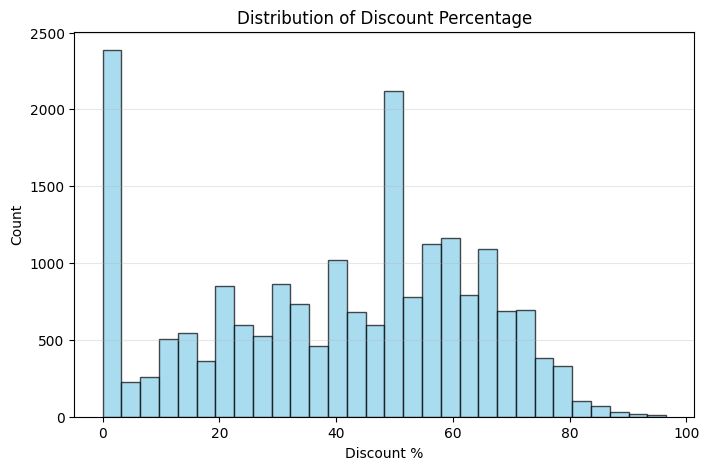

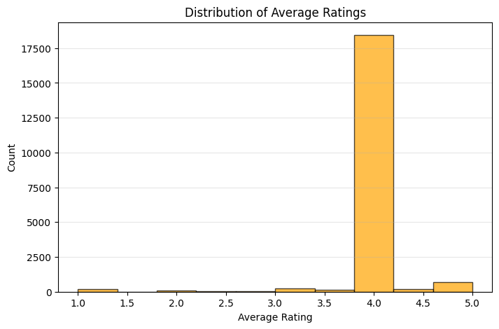

```python
# 1.Distribution of Discount in Percentages

plt.figure(figsize=(8,5))
plt.hist(product_features['discount_pct'], bins=30, color='skyblue', edgecolor='black', alpha=0.7)
plt.title('Distribution of Discount Percentage')
plt.xlabel('Discount %')
plt.ylabel('Count')
plt.grid(axis='y', alpha=0.3)
plt.show()

# 2.Distribution of Average Ratings

plt.figure(figsize=(8,5))
plt.hist(product_features['average_rating'], bins=10, color='orange', edgecolor='black', alpha=0.7)
plt.title('Distribution of Average Ratings')
plt.xlabel('Average Rating')
plt.ylabel('Count')
plt.grid(axis='y', alpha=0.3)
plt.show()
```

Temporal Features:-

Timestamp features:

1. Month/year of crawl
2. Day of week
3. Time of day
4. Seasonal flag

```python
#Used to Extract different temporal features from the timestamp:

df['crawl_timestamp'] = pd.to_datetime(df['crawl_timestamp'], errors='coerce')
df['month'] = df['crawl_timestamp'].dt.month
df['year'] = df['crawl_timestamp'].dt.year
df['day_of_week'] = df['crawl_timestamp'].dt.dayofweek
df['hour'] = df['crawl_timestamp'].dt.hour

# Creating time-of-day categories based on hours
def time_of_day(hour):
    if 5 <= hour < 12:
        return 'Morning'
    elif 12 <= hour < 17:
        return 'Afternoon'
    elif 17 <= hour < 21:
        return 'Evening'
    else:
        return 'Night'

df['time_of_day'] = df['hour'].apply(time_of_day)


# 4. Seasonal Flag

def season(month):
    if month in [12, 1, 2]:
        return 'Winter'
    elif month in [3, 4, 5]:
        return 'Spring'
    elif month in [6, 7, 8]:
        return 'Summer'
    else:
        return 'Autumn'

df['season'] = df['month'].apply(season)


#Display new temporal features

temporal_features = df[['crawl_timestamp', 'year', 'month', 'day_of_week', 'hour', 'time_of_day', 'season']]
temporal_features.head()
```

|  | crawl_timestamp | year | month | day_of_week | hour | time_of_day | season |
| --- | --- | --- | --- | --- | --- | --- | --- |
| 0 | 2016-03-25 22:59:23+00:00 | 2016 | 3 | 4 | 22 | Night | Spring |
| 1 | 2016-03-25 22:59:23+00:00 | 2016 | 3 | 4 | 22 | Night | Spring |
| 2 | 2016-03-25 22:59:23+00:00 | 2016 | 3 | 4 | 22 | Night | Spring |
| 3 | 2016-03-25 22:59:23+00:00 | 2016 | 3 | 4 | 22 | Night | Spring |
| 4 | 2016-03-25 22:59:23+00:00 | 2016 | 3 | 4 | 22 | Night | Spring |

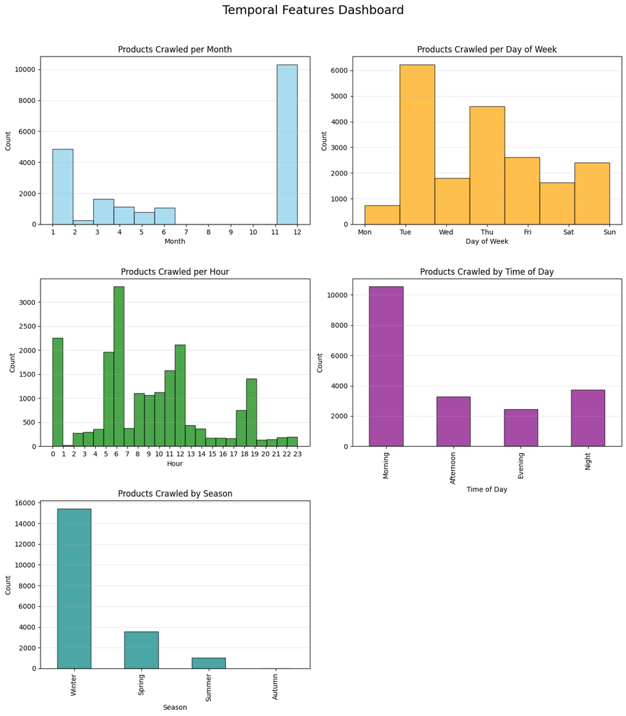

```python
# Creating a dashboard with 3x2 subplots
fig, axes = plt.subplots(3, 2, figsize=(13,15))
fig.suptitle('Temporal Features Dashboard', fontsize=18)


# 1. Products Crawled per Month
axes[0,0].hist(temporal_features['month'], bins=12, range=(1,12), color='skyblue', edgecolor='black', alpha=0.7)
axes[0,0].set_title('Products Crawled per Month')
axes[0,0].set_xlabel('Month')
axes[0,0].set_ylabel('Count')
axes[0,0].set_xticks(range(1,13))
axes[0,0].grid(axis='y', alpha=0.3)


# 2. Products Crawled per Day in a Week
axes[0,1].hist(temporal_features['day_of_week'], bins=7, range=(0,6), color='orange', edgecolor='black', alpha=0.7)
axes[0,1].set_title('Products Crawled per Day of Week')
axes[0,1].set_xlabel('Day of Week')
axes[0,1].set_ylabel('Count')
axes[0,1].set_xticks(range(0,7))
axes[0,1].set_xticklabels(['Mon','Tue','Wed','Thu','Fri','Sat','Sun'])
axes[0,1].grid(axis='y', alpha=0.3)


# 3. Products Crawled per Hour
axes[1,0].hist(temporal_features['hour'], bins=24, range=(0,23), color='green', edgecolor='black', alpha=0.7)
axes[1,0].set_title('Products Crawled per Hour')
axes[1,0].set_xlabel('Hour')
axes[1,0].set_ylabel('Count')
axes[1,0].set_xticks(range(0,24))
axes[1,0].grid(axis='y', alpha=0.3)


# 4. Products Crawled by Time in a Day
temporal_features['time_of_day'].value_counts().reindex(['Morning','Afternoon','Evening','Night']).plot(
    kind='bar', ax=axes[1,1], color='purple', edgecolor='black', alpha=0.7)
axes[1,1].set_title('Products Crawled by Time of Day')
axes[1,1].set_xlabel('Time of Day')
axes[1,1].set_ylabel('Count')
axes[1,1].grid(axis='y', alpha=0.3)


# 5. Products Crawled by Season
temporal_features['season'].value_counts().reindex(['Winter','Spring','Summer','Autumn']).plot(
    kind='bar', ax=axes[2,0], color='teal', edgecolor='black', alpha=0.7)
axes[2,0].set_title('Products Crawled by Season')
axes[2,0].set_xlabel('Season')
axes[2,0].set_ylabel('Count')
axes[2,0].grid(axis='y', alpha=0.3)


# 6. Hide the last empty subplot
axes[2,1].axis('off')
plt.tight_layout(rect=[0, 0, 1, 0.96])
plt.show()
```

# Group By:

1. Brand Level Features

```python
#To creates a brand-level summary

brand_features = df.groupby('brand').agg(avg_price=('discounted_price', 'mean'),avg_rating=('average_rating', 'mean'),avg_discount=('discount_pct', 'mean'),
                 num_products=('pid', 'count')).reset_index()

brand_features.head()
```

|  | brand | avg_price | avg_rating | avg_discount | num_products |
| --- | --- | --- | --- | --- | --- |
| 0 | 1OAK | 637.000000 | 4.000000 | 24.973932 | 2 |
| 1 | 3D Mat | 6999.000000 | 4.000000 | 3.462069 | 1 |
| 2 | 3a AUTOCARE | 1827.826087 | 4.000000 | 29.795834 | 23 |
| 3 | 3a Autocare | 1783.000000 | 4.055556 | 34.037777 | 18 |
| 4 | 3kFactory | 174.000000 | 4.000000 | 56.390977 | 1 |

2. Category-Level Features

```python
# Group by category and calculate aggregates
category_features = df.groupby('product_category_tree').agg(avg_price=('discounted_price', 'mean'),avg_rating=('average_rating', 'mean'),
    avg_discount=('discount_pct', 'mean'),num_products=('pid', 'count')).reset_index()

# Create bins for number of products per each category
# Example: 0-5, 6-10, 11-20, 21+

bins = [0, 5, 10, 20, float('inf')]
labels = ['0-5', '6-10', '11-20', '21+']
category_features['num_products_bin'] = pd.cut(category_features['num_products'], bins=bins, labels=labels)

# Create bins for average price per category
# Example: cheap, mid, expensive

price_bins = [0, 500, 2000, float('inf')]
price_labels = ['Cheap', 'Mid-range', 'Expensive']
category_features['price_bin'] = pd.cut(category_features['avg_price'], bins=price_bins, labels=price_labels)

category_features.head()
```

|  | product_category_tree | avg_price | avg_rating | avg_discount | num_products | num_products_bin | price_bin |
| --- | --- | --- | --- | --- | --- | --- | --- |
| 0 | ["883 Police Full Sleeve Solid Men's Jacket"] | 6374.0 | 4.0 | 15.002000 | 1 | 0-5 | Expensive |
| 1 | ["ABEEZ Boys, Men, Girls (Black, Pack of 1)"] | 289.0 | 4.0 | 27.568922 | 1 | 0-5 | Cheap |
| 2 | ["ANAND ARCHIES Girls Flats"] | 449.0 | 4.0 | 10.020040 | 2 | 0-5 | Cheap |
| 3 | ["ANAND ARCHIES Girls Wedges"] | 899.0 | 4.0 | 0.000000 | 1 | 0-5 | Mid-range |
| 4 | ["ANASAZI Casual 3/4 Sleeve Solid Women's Top"] | 899.0 | 4.0 | 0.000000 | 1 | 0-5 | Mid-range |

Now the dataset is alright for EDA. I'm setting up some business problems one by one and performing EDA to find the answers for the business problems questions.

# **Business questions:-**

1. Which product categories offer the highest discounts but maintain high ratings?

   This code gives which product categories give big discounts and still have good customer ratings. It calculates the average rating and discount for each category, then considers categories with at least 30% discount and ratings of 4 or higher, shows the top ones.

```python
# Assuming df already has average_rating and discount_pct calculated
# If not, make sure to convert 'No rating available' to NaN and then to numeric
df['average_rating'] = pd.to_numeric(df['average_rating'], errors='coerce')
df['discount_pct'] = pd.to_numeric(df['discount_pct'], errors='coerce')


# Group by product category and calculate average rating and discount
category_stats = df.groupby('product_category_tree').agg(avg_rating=('average_rating', 'mean'),avg_discount=('discount_pct', 'mean'),
                  num_products=('pid', 'count')).reset_index()


# Filter for categories with high discount and high rating
high_discount_threshold = 30    # e.g: 30% discount,we can adjust thresholds as needed
high_rating_threshold = 4.0     # e.g: rating >= 4
best_categories = category_stats[(category_stats['avg_discount'] >= high_discount_threshold) & (category_stats['avg_rating'] >= high_rating_threshold)
].sort_values(by=['avg_discount','avg_rating'], ascending=False)

best_categories.head(5)
```

|  | product_category_tree | avg_rating | avg_discount | num_products |
| --- | --- | --- | --- | --- |
| 1023 | ["Beauty and Personal Care >> Makeup >> Vanity... | 4.0 | 91.952663 | 1 |
| 3417 | ["Computers >> Laptop Accessories >> USB Gadge... | 4.0 | 91.719745 | 1 |
| 5283 | ["Mobiles & Accessories >> Mobile Accessories ... | 5.0 | 91.596639 | 1 |
| 429 | ["Baby Care >> Infant Wear >> Baby Boys' Cloth... | 4.0 | 90.900819 | 1 |
| 3085 | ["Clothing >> Women's Clothing >> Western Wear... | 4.0 | 90.045023 | 1 |

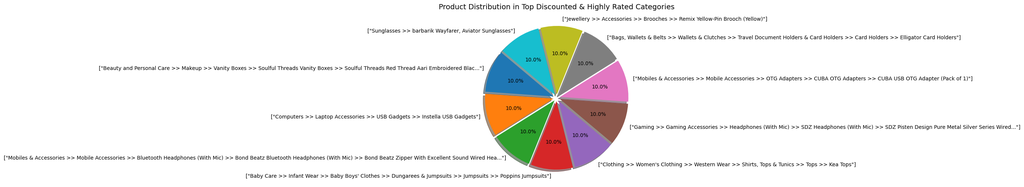

```python
#Step 1:Take top 10 best categories
top_categories = best_categories.head(10)

#Step 2:Prepare pie chart
plt.figure(figsize=(12,6))
plt.pie(
    top_categories['num_products'],                       # Sizes of slices
    labels=top_categories['product_category_tree'],       # Labels for slices
    autopct='%1.1f%%',                                    # Show percentage
    startangle=140,                                       # Rotate start angle
    explode=[0.05]*len(top_categories),                   # Slightly separate each slice
    shadow=True)                                          # Add shadow for 3D effect

plt.title('Product Distribution in Top Discounted & Highly Rated Categories', fontsize=14)
plt.tight_layout(pad=2.0)
plt.show()
```

2. Which product price ranges generate the most products and highest average ratings?

```python
# Ensuring discounted price is numeric
df['discounted_price'] = pd.to_numeric(df['discounted_price'], errors='coerce')

# Creating price bins
price_bins = [0, 200, 500, 1000, 2000, 5000, float('inf')]
price_labels = ['0-200', '201-500', '501-1000', '1001-2000', '2001-5000', '5000+']
df['price_range'] = pd.cut(df['discounted_price'], bins=price_bins, labels=price_labels)
```

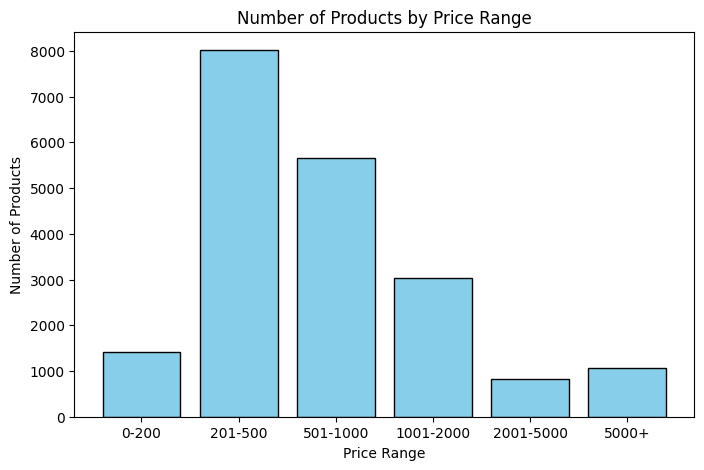

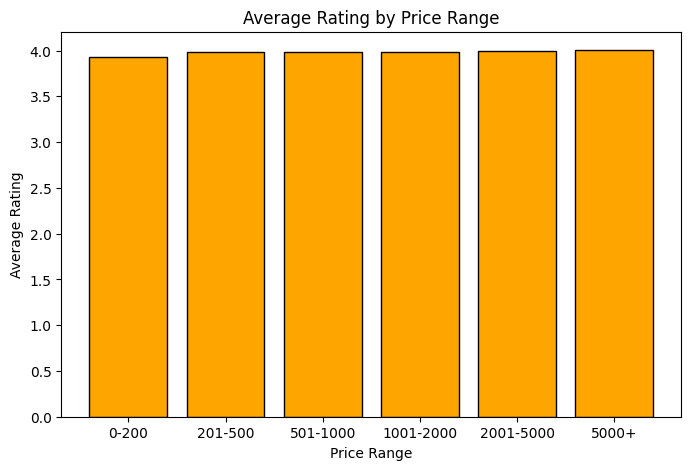

```python
# Group by price range and calculate number of products and average rating
price_stats = df.groupby('price_range').agg(num_products=('pid', 'count'),
    avg_rating=('average_rating', 'mean')).reset_index()

plt.figure(figsize=(8,5))
plt.bar(price_stats['price_range'], price_stats['num_products'], color='skyblue', edgecolor='black')
plt.title('Number of Products by Price Range')
plt.xlabel('Price Range')
plt.ylabel('Number of Products')
plt.show()

plt.figure(figsize=(8,5))
plt.bar(price_stats['price_range'], price_stats['avg_rating'], color='orange', edgecolor='black')
plt.title('Average Rating by Price Range')
plt.xlabel('Price Range')
plt.ylabel('Average Rating')
plt.show()
```

3. "Does offering higher discounts actually lead to better customer ratings, or does it only lower the price without improving satisfaction?"

```python
# Picking only numeric columns
numeric_df = df[['retail_price', 'discounted_price', 'discount_pct', 'average_rating']].copy()

# Converting to numeric if average_rating has "No rating available"
numeric_df['average_rating'] = pd.to_numeric(numeric_df['average_rating'], errors='coerce')

# Compute correlation matrix
corr_matrix = numeric_df.corr()
```

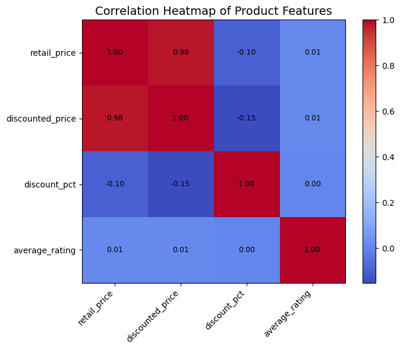

```python
plt.figure(figsize=(8,6))
heatmap = plt.imshow(corr_matrix, cmap='coolwarm', interpolation='nearest')

# Add colorbar
plt.colorbar(heatmap, fraction=0.046, pad=0.04)

# Add ticks
plt.xticks(range(len(corr_matrix)), corr_matrix.columns, rotation=45, ha='right')
plt.yticks(range(len(corr_matrix)), corr_matrix.columns)

# Add values inside heatmap
for i in range(len(corr_matrix)):
    for j in range(len(corr_matrix)):
        plt.text(j, i, f"{corr_matrix.iloc[i, j]:.2f}",
                 ha='center', va='center', color='black', fontsize=9)

plt.title("Correlation Heatmap of Product Features", fontsize=14)
plt.tight_layout()
plt.show()
```

4. "How do discount strategies vary among the top 10 brands, and which brands tend to offer higher or lower discounts on their products?"

   Among the top 10 brands,some depend on higher discounts to attract more buyers,while others keep smaller discounts and focus on brand value.Brands offering bigger discounts compete on price,while premium brands use lower discounts to maintain quality image.

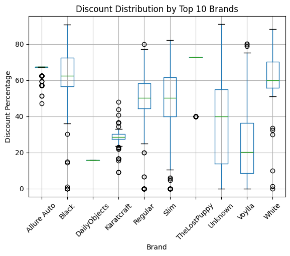

```python
# Picking top 10 brands by product count for clarity
top_brands = df['brand'].value_counts().head(10).index
df_top_brands = df[df['brand'].isin(top_brands)]

plt.figure(figsize=(12,6))
df_top_brands.boxplot(column='discount_pct', by='brand', grid=True)
plt.title('Discount Distribution by Top 10 Brands')
plt.suptitle('')  # Remove automatic subtitle
plt.xlabel('Brand')
plt.ylabel('Discount Percentage')
plt.xticks(rotation=45)
plt.show()
```

5. “How does the average product discount change across different months of the year?”

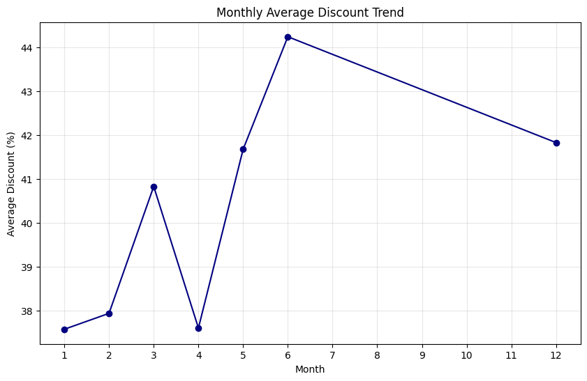

```python
# Convert timestamp
df['crawl_timestamp'] = pd.to_datetime(df['crawl_timestamp'], errors='coerce')

# Extract month
df['month'] = df['crawl_timestamp'].dt.month

# Aggregate monthly average discount
monthly_discount = df.groupby('month')['discount_pct'].mean()

# Visualization
plt.figure(figsize=(10,6))
monthly_discount.plot(kind='line', marker='o', color='navy')
plt.title('Monthly Average Discount Trend')
plt.xlabel('Month')
plt.ylabel('Average Discount (%)')
plt.xticks(range(1,13))  # Ensure months 1-12
plt.grid(True, alpha=0.3)
plt.show()
```

6. "Is there a relationship between product price and customer ratings.Do high priced products consistently receive better ratings compared to low priced ones?

   Product price has little effect on customer ratings, expensive items don’t always get higher ratings.Customers seem to give rating more based on quality and experience than the price.

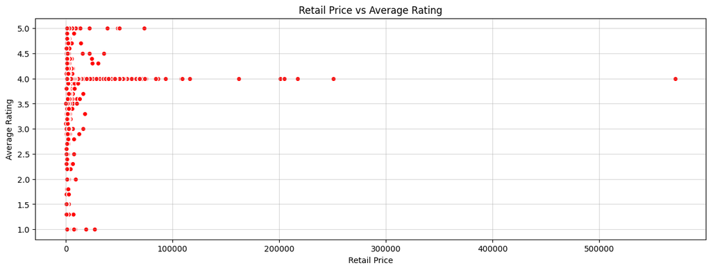

```python
plt.figure(figsize=(15,5))
plt.scatter(df['retail_price'], df['average_rating'], alpha=1, color='Red', edgecolors='w')
plt.title("Retail Price vs Average Rating")
plt.xlabel("Retail Price")
plt.ylabel("Average Rating")
plt.grid(True, alpha=0.5)
plt.show()
```

# **CONCLUSION**:

The dataset is just historical, some categories have fewer goods, and we don't have comprehensive transactional data, which are all restrictions. Flipkart may use our findings to concentrate on its best selling products and brands develop its marketing and pricing strategies, and improve its offerings in lower-rated sectors. These ideas can help flipkart make better choices, boost revenue, and retain its clientele.

# References:

1. McKinney.W,Python for Data Analysis:Pandas, NumPy, and IPython.Link:- https://www.oreilly.com/library/view/python-for-data/9781491957653/
2. Seaborn Document, 2024.Seaborn: Python-Based Statistical Data Visualization. accessible via https://seaborn.pydata.org
3. Hair J.F., Black W.C., Babin B.J., Anderson R.E., and Tatham R.L. (2010). Link: https://www.drnishikantjha.com/papersCollection/Multivariate%20Data%20Analysis.pdf Multivariate Data Analysis
4. J.W. Tukey, Exploratory Data Analysis, 1977. Wesley & Addison. accessible via this link: https://www.ru.ac.bd/stat/wp-content/uploads/sites/25/2019/03/1977-Tukey-Exploratory-Data-Analysis.pdf
5. Matplotlib: A 2D Graphics Environment, Hunter J.D. accessible via this link: https://ieeexplore.ieee.org/document/4160265
6. Financial Services Customer Attrition Analysis Employing Logistic Regression Methods.Lariviere.B,and Van den Poel(2004).The article can be found at https://www.sciencedirect.com/science/article/abs/pii/S0377221703000699.
7. Friendly M. (2007). An Overview of Data Visualization History.The Handbook of Computational Statistics can be found at https://www.datavis.ca/papers/history.pdf.